# FaceExpressionRecognition_CNN_Keras_Theano

## Creating this doc as a report to the work Done on the Convolutional Neaural Networks

```python
## Importing all visualization libaries
import matplotlib.pyplot as plt
import matplotlib
import brewer2mpl
import numpy as np
import pandas as pd
```

```python
## Im using the Keras for ease of neural network creation and using the Theano in the background
from keras.layers import Convolution2D, MaxPooling2D
from keras.layers import Activation, Dropout, Flatten, Dense
from keras.models import Sequential
from keras.models import model_from_json
from keras.preprocessing.image import ImageDataGenerator
from IPython.display import Image
```

```
Using Theano backend.
```

```python
# sset matplotlib in inline so that we can see all the plots in the notebook itself
ColorPalletSet3 = brewer2mpl.get_map('Set3', 'qualitative', 6).mpl_colors
%matplotlib inline
```

```python
# First lets visualize some data that I have used for the project
# The data is taken from the Kaggle competetion
```

```python
### Display some faces with their expression.
# lets load the data
# loading the training data of some faces
# i have created the data and saved as numpy arays to avoid processing every time I want to do some tasks
XTrainingData = "D:/sem4/ComputerVision/CNN-Proj/Code-FaceRecognition/fer2013/DataInNumpyForTrainingAndTesting/XData_Training.npy"
yTrainingData = "D:/sem4/ComputerVision/CNN-Proj/Code-FaceRecognition/fer2013/DataInNumpyForTrainingAndTesting/yData_Training.npy"
X = np.load(XTrainingData)
y = np.load(yTrainingData)
print "Data Loaded to visualize"
```

```
Data Loaded to visualize
```

[figure not shown]

```python
fig = plt.figure(figsize=(15,12))
for i in range(36):
    imageAtI = X[i:(i+1),:,:,:]
    SubPlotArea = fig.add_subplot(6,6,i+1)
    SubPlotArea.imshow(imageAtI[0,0,:,:], cmap=matplotlib.cm.gray)
plt.show()
```

Since this is a onvolutional Neural network, the neural net should have learned the filters throuugh forard and backward propagation. lets see the filters those creeated for the model through the forward and backward propagations.

### Loading Model and Weights

1. we have the model that is created through the CNN training
2. this model has all the information and parmaetrrs that the CNN has learned
3. lets load that model to check its filters
4. the model with the number of layers, max-pooling, and all other layers information is stored in the model
5. the weights of the model are stored in the file too. Lets load both of them, load json and create model

```python
ModelSavedAsJson = open("D:/sem4/ComputerVision/CNN-Proj/Code-FaceRecognition/fer2013/Model/model.json",'r')
CNNmodelForFaceExpresions = model_from_json(ModelSavedAsJson.read())
# loading the weights into the model to reconstruct the complete structire of the convolutional neural network.
CNNmodelForFaceExpresions.load_weights("D:/sem4/ComputerVision/CNN-Proj/Code-FaceRecognition/fer2013/Model/model.h5")
ModelSavedAsJson.close()
print "The Model got sucessfully loaded and it helps to undersand the various details of the CNN that got created"
```

```
The Model got sucessfully loaded and it helps to undersand the various details of the CNN that got created
```

### Exploring Fiters of the CNN modeled :

since we have loaded the model, now lets look into the filters

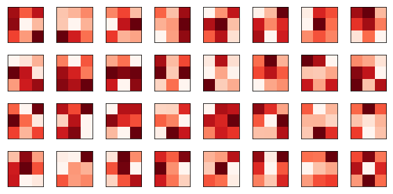

```python
FilterValuesAtLayer = CNNmodelForFaceExpresions.layers[0].W.get_value()
fig = plt.figure(figsize=(8, 4))
for IthNeuronUnit in range(len(FilterValuesAtLayer)):
    SubPlotAreaProps = fig.add_subplot(4, 8, IthNeuronUnit+1)
    SubPlotAreaProps.matshow(FilterValuesAtLayer[IthNeuronUnit][0], cmap = matplotlib.cm.Reds)
    plt.xticks(np.array([]))
    plt.yticks(np.array([]))
    plt.tight_layout()
```

### Filter At Layer 4

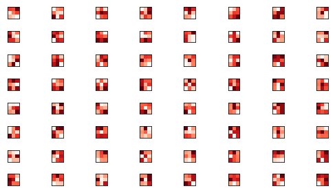

```python
FilterValuesAtLayer = CNNmodelForFaceExpresions.layers[4].W.get_value()
fig = plt.figure(figsize=(8, 4))
for IthNeuronUnit in range(len(FilterValuesAtLayer)):
    SubPlotAreaProps = fig.add_subplot(8,8, IthNeuronUnit+1)
    SubPlotAreaProps.matshow(FilterValuesAtLayer[IthNeuronUnit][0], cmap = matplotlib.cm.Reds)
    plt.xticks(np.array([]))
    plt.yticks(np.array([]))
    plt.tight_layout()
```

### Now lets take a human face and see how that is being fitered over the CNN at different layers

We shall use theano for this

1. we shall use one simple thenao funciton;
2. the goal is to show how the input image gets convoluted and learned by the time it reaches a particular layer

```python
# lets take first one input image as we did earlier
```

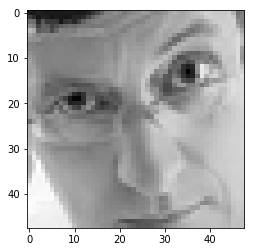

```python
SampleFaceImage = X[0:1,:,:,:]
plt.imshow(SampleFaceImage[0,0,:,:], cmap='gray')
```

```python
import theano
def LearningAsReachedALayer(SampleFaceImage,UntilWhichLayer):
    colormaps=True
    feedForwardOnCNN= theano.function([CNNmodelForFaceExpresions.layers[0].input],CNNmodelForFaceExpresions.layers[UntilWhichLayer].output, allow_input_downcast=True)

    ForwardPropResultAtRequiredlayer = feedForwardOnCNN(SampleFaceImage)
    ## Now each unit has learned something and lets iterate over the units of the result and plot.
    #The imge is changed as it reached various layers
    Totalfilters = ForwardPropResultAtRequiredlayer.shape[1]

    fig = plt.figure(figsize=(15,10))

    for EachUnit in range(Totalfilters):
        SubPlotAreaProps = fig.add_subplot(Totalfilters/16,16,EachUnit+1)
        SubPlotAreaProps.imshow(ForwardPropResultAtRequiredlayer[0,EachUnit,:,:], cmap='Blues')
        ## below are common to avoid the axes nubmbering eetc.. while plotting
        plt.xticks(np.array([]))
        plt.yticks(np.array([]))
        plt.tight_layout()
    plt.show()
```

```python
## The above image after Layer 11
#LearningAsReachedALayer(SampleFaceImage,11)
## from layer 0 the input is passedd and at the layer 11 the filter is as below
```

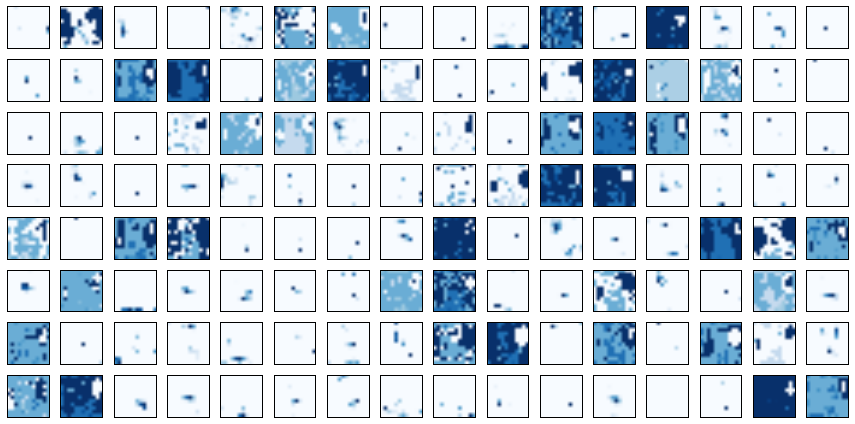

```python
LearningAsReachedALayer(SampleFaceImage,11)
```